# Estudis d'Informàtica, Multimedia i Telecomunicacions

# M2.959 - PAC2 - Alluvial Diagram

Autor: Carles Sanchez Vilaro

Abril 2025

# 1 Context

En aquesta segona pràctica, desenvoluparem un diagrama alluvial basat en incidents amb taurons, per analitzar la relació entre l’espècie de l’animal, la tipologia de l’atac i si aquest va ser mortal. El conjunt de dades prové de Kaggle, i el seu autor és Gaurav Kumar. Aquesta recopilació ha estat elaborada a partir del repositori Global Shark Attack File (GSAF) amb registres històrics i moderns (fins 2023), i es distribueix sota la llicència Apache 2.0.

Font: https://www.kaggle.com/datasets/gauravkumar2525/shark-attacks

# 2 Carrega de dades i llibreries

Carreguem les llibreries necessàries i el conjunt de dades.

```r
llibreries <- c("knitr",
                "dplyr",
                "stringr",
                "forcats",
                "ggplot2",
                "ggalluvial")

llibreries_a_instalar <- llibreries[!(llibreries %in% installed.packages()[,"Package"])]
if(length(llibreries_a_instalar)) install.packages(llibreries_a_instalar)

llibreries_carregades <- lapply(llibreries, library, character.only = TRUE)

atacs_taurons <- read.csv("global_shark_attacks.csv")
glimpse(atacs_taurons)
```

```
## Rows: 6,890
## Columns: 13
## $ date      <chr> "2023-05-13", "2023-04-29", "2022-10-07", "2021-10-04", "202…
## $ year      <dbl> 2023, 2023, 2022, 2021, 2021, 2021, 2021, 2021, 2021, 2021, …
## $ type      <chr> "Unprovoked", "Unprovoked", "Unprovoked", "Unprovoked", "Unp…
## $ country   <chr> "AUSTRALIA", "AUSTRALIA", "AUSTRALIA", "USA", "USA", "USA", …
## $ area      <chr> "South Australia", "Western Australia", "Western  Australia"…
## $ location  <chr> "Elliston", "Yallingup, Busselton", "Port Hedland", "Fort Pi…
## $ activity  <chr> "Surfing", "Swimming", "Spearfishing", "Surfing", "Swimming"…
## $ name      <chr> "Simon Baccanello", "male", "Robbie Peck", "Truman Van Patri…
## $ sex       <chr> "M", "M", "M", "M", "M", "M", "M", "M", "F", "F", "M", "M", …
## $ age       <chr> "46", "", "38", "25.0", "", "26.0", "14.0", "53.0", "16.0", …
## $ fatal_y_n <chr> "Y", "N", "N", "N", "N", "N", "N", "Y", "N", "N", "N", "N", …
## $ time      <chr> "10h10", "11h20", "11h30", "", "12h00", "", "16h00", "08h00"…
## $ species   <chr> "White shark", "1m shark", "Bull shark", "", "", "5' shark",…
```

Descrivim les variables:

- **date** La data específica en què va tenir lloc l’atac.
- **year** L’any de l’incident.
- **type** Classificació de l’atac (per exemple, no provocat, provocat).
- **country** El país on va tenir lloc l’incident.
- **area** La regió específica dins del país.
- **location** La ubicació exacta o platja on va succeir l’atac.
- **activity** L’activitat que la persona realitzava en el moment (per exemple, surfejar, nedar).
- **name** El nom de l’individu involucrat en l’atac.
- **sex** El gènere de l’individu (M/F).
- **age** L’edat de l’individu involucrat en l’incident.
- **fatal_y_n** Indica si l’atac va ser mortal (Y per Sí, N per No).
- **rime** L’hora aproximada de l’atac.
- **species** L’espècie de tauró involucrada, si s’ha identificat.

# 3 Neteja de dades

Codifiquem les tres variables rellevants per al diagrama i seleccionem únicament les files que contenen dades vàlides.

Espècie:

```r
especies_taurons <- c("white", "sand tiger", "tiger", "bull", "mako",
                      "lemon", "whitetip", "blue", "galapagos", "caribbean reef",
                      "dusky", "blacktip reef", "blacktip", "silky", "gray reef",
                      "hammerhead", "broadnose", "bluntnose", "nurse", "wobbegong",
                      "basking", "spinner", "bronze")

regex_especies <- paste0("\\b(", paste(especies_taurons, collapse = "|"), ")\\b")

atacs_taurons <- atacs_taurons %>%
  mutate(especie = str_extract(tolower(species), regex_especies)) %>%
  filter(!is.na(especie)) %>%
  mutate(especie = paste0(especie, " shark"))

# Espècies relaciones amb atacs segons GSAF
# https://www.sharkattackfile.net/species.htm
```

Tipus d’atac:

```r
atacs_taurons <- atacs_taurons %>%
  filter(!is.na(type) & type != "") %>%
  filter(!type %in% c("Invalid", "Questionable")) %>%
  mutate(tipus_atac = if_else(type %in% c("Unprovoked", "Provoked"),
                              type,
                              "Other sea incidents"))
```

Atac Mortal:

```r
atacs_taurons <- atacs_taurons %>%
  filter(fatal_y_n %in% c("Y", "N")) %>%
  mutate(atac_mortal = case_when(
    fatal_y_n == "Y" ~ "Yes",
    fatal_y_n == "N" ~ "No"))
```

Seleccionem les variables i les codifiquem:

```r
atacs_taurons <- atacs_taurons %>%
  select(especie, tipus_atac, atac_mortal) %>%
  mutate(across(everything(), as.factor))
```

# 4 Alluvial Diagram

Generem el gràfic filtrant per les top 5 espècies.

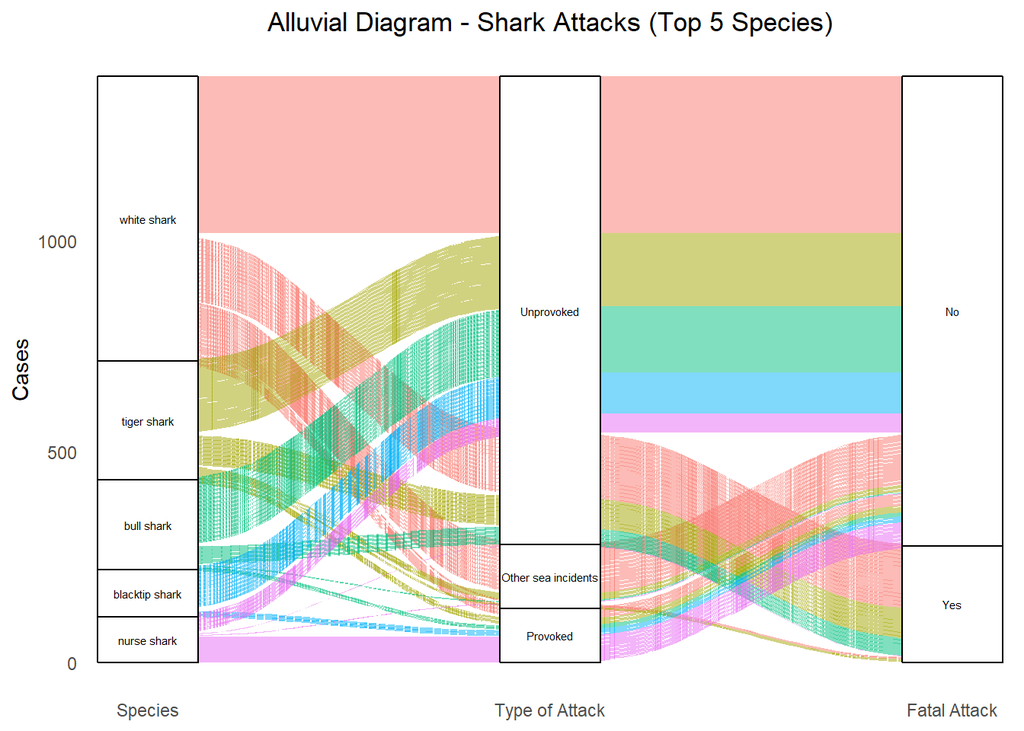

```r
top_5_especies <- atacs_taurons %>%
  count(especie, sort = TRUE) %>%
  top_n(5, n) %>%
  pull(especie)

atacs_taurons_top5 <- atacs_taurons %>%
  filter(especie %in% top_5_especies) %>%
  mutate(
    especie = fct_infreq(as.factor(especie)),
    tipus_atac = fct_infreq(as.factor(tipus_atac)),
    atac_mortal = fct_infreq(as.factor(atac_mortal)))

ggplot(atacs_taurons_top5, aes(axis1 = especie, axis2 = tipus_atac, axis3 = atac_mortal, y = ..count..)) +
  geom_alluvium(aes(fill = especie), aes.bind=TRUE, width = 1/12) +
  geom_stratum(width = 1/4, fill = "white", color = "black") +
  geom_text(stat = "stratum", aes(label = after_stat(stratum), y = after_stat(y)), size = 2) +
  scale_x_discrete(limits = c("especie", "tipus_atac", "atac_mortal"),
                   labels = c("Species", "Type of Attack", "Fatal Attack"),
                   expand = c(.05, .05)) +
  labs(y = "Cases") +
  theme_minimal() +
  theme(plot.title = element_text(hjust = 0.5),
        panel.grid = element_blank(),
        legend.position = "none") +
  ggtitle("Alluvial Diagram - Shark Attacks (Top 5 Species)")
```

# 5 Conclusió

Aquest diagrama alluvial ens mostra el flux d’incidents amb taurons. La majoria d’incidents registrats es concentren en espècies com el tauró blanc i el tauró tigre, i es classifiquen principalment com a no provocats. Pel que fa a la sinistralitat, predominen els casos que no acaben sent mortals, tot i que hi ha un flux menor cap a atacs que sí que resulten fatals.